# Data606_Final Project

Vijaya Cherukuri

12/8/2019

[output not shown]

### **Defining libraries**:

```r
library(tidyr)
library(dplyr)
```

```r
library(psych)
library(stringr)
library(ggplot2)
library(MASS)
```

### **Part 1 - Introduction**

### **Introduction: What is your research question? Why do you care? Why should others care?**

#### Which college majors offer the best opportunities in terms of unemployment rate and salary?

#### The rise of College costs occuring slowly. Every student was thinking how much that he has to spent on their studies. There needs to be some change in public policy in such a way that makes higher education more affordable to more people, prospective students may have to make hard choices about how much debt they take on, and how quickly they can pay down that debt. Employment rates and salary statistics are important for cost-conscience students to choose a path that not encumber a student with unmanageable debt. To address these concerns i took that question.

### **Part 2 - Data**

#### **Data collection: Describe how the data were collected.**

#### These Data were collated by the 538 website and was posted to their github page4. They in turn used data from:

#### “All data is from American Community Survey 2010-2012 Public Use Microdata Series.

#### Download data here: http://www.census.gov/programs-surveys/acs/data/pums.html

#### Documentation here: http://www.census.gov/programs-surveys/acs/technical-documentation/pums.html

#### Major categories are from Carnevale et al,”What’s It Worth?: The Economic Value of College Majors." Georgetown University Center on Education and the Workforce, 2011.5" Details for the Georgetown data set can be found here: https://1gyhoq479ufd3yna29x7ubjn-wpengine.netdna-ssl.com/wp-content/uploads/2015/01/WIW1-Methodology.pdf

#### **Cases: What are the cases? (Remember: case = units of observation or units of experiment)**

#### In many observational surveys the cases are individual people. That is not true for this study. Although the data was collected by asking individuals what their major, degree level, pay, and employment status was. The data is organized in such a way that the cases are the college majors. In the “All_ages” set," each case represents majors offered by colleges and universities in the US. These data include both undergrads and grad students. In the “Grad_students” set, each case represents majors offered by colleges and universities in the US. These data include only grad students aged 25+ years. Finally, in the “Recent_grad” set, each case represents majors offered by colleges and universities in the US. These data include only undergraduate students aged <28 years. “Recent_grad” also includes gender statistics. In all sets, the same 173 majors are used.

#### **Variables: What are the two variables you will be studying? State the type of each variable.**

#### The response variables are college majors which is categorical. Results will take the form of ordered lists. These lists will be created using the explanatory variables such as the counts of employed and unemployed college degree holders and the statistics of their income. These data are numerical.

#### **Type of study: What is the type of study, observational or an experiment? Explain how you’ve arrived at your conclusion using information on the sampling and/or experimental design.**

#### This is an observational study. Since these data were collected by survey and lacks experimental features like a control group and blinding. We therefore cannot establish a causal link between variables. However the sample size is small enough compared to the population where cases are independent, and the data were collected at random. We can make inferences and predictions using these data.

#### **Scope of inference - generalizability: Identify the population of interest, and whether the findings from this analysis can be generalized to that population, or, if not, a subsection of that population. Explain why or why not. Also discuss any potential sources of bias that might prevent generalizability.**

#### The data that we collected is from the samples from US degree holders. This data was a portion and not collected from the other countries. Whatever the prediction that we make here is only relevent with in the US.

#### **Scope of inference - causality: Can these data be used to establish causal links between the variables of interest? Explain why or why not**.

#### We cannot establish a causal link between variables. However the sample size is small enough compared to the population where cases are independent, and the data were collected at random. We can make inferences and predictions using these data.

```r
all_ages_df <-  read.csv(file ="https://raw.githubusercontent.com/fivethirtyeight/data/master/college-majors/all-ages.csv", header= TRUE)
names(all_ages_df)
```

```
##  [1] "Major_code"                    "Major"
##  [3] "Major_category"                "Total"
##  [5] "Employed"                      "Employed_full_time_year_round"
##  [7] "Unemployed"                    "Unemployment_rate"
##  [9] "Median"                        "P25th"
## [11] "P75th"
```

```r
all_ages_df_eng <- all_ages_df %>% filter(Major_category == "Engineering")
head(all_ages_df_eng)
```

```
##   Major_code                     Major Major_category  Total Employed
## 1       1401              ARCHITECTURE    Engineering 294692   216770
## 2       2400       GENERAL ENGINEERING    Engineering 503080   359172
## 3       2401     AEROSPACE ENGINEERING    Engineering  65734    44944
## 4       2402    BIOLOGICAL ENGINEERING    Engineering  32748    24270
## 5       2403 ARCHITECTURAL ENGINEERING    Engineering  19587    13713
## 6       2404    BIOMEDICAL ENGINEERING    Engineering  18347    12876
##   Employed_full_time_year_round Unemployed Unemployment_rate Median P25th
## 1                        163020      20394        0.08599113  63000 40400
## 2                        312023      17986        0.04768824  75000 50000
## 3                         38491       1969        0.04197131  80000 58000
## 4                         18621       1521        0.05897406  62000 40000
## 5                         11180       1017        0.06904277  78000 50000
## 6                          9202       1105        0.07903583  65000 40000
##    P75th
## 1  93500
## 2 100000
## 3 110000
## 4  91000
## 5 102000
## 6  96000
```

```r
grad_df <-  read.csv(file = "https://raw.githubusercontent.com/fivethirtyeight/data/master/college-majors/grad-students.csv", header= TRUE)
names(grad_df)
```

```
##  [1] "Major_code"                   "Major"
##  [3] "Major_category"               "Grad_total"
##  [5] "Grad_sample_size"             "Grad_employed"
##  [7] "Grad_full_time_year_round"    "Grad_unemployed"
##  [9] "Grad_unemployment_rate"       "Grad_median"
## [11] "Grad_P25"                     "Grad_P75"
## [13] "Nongrad_total"                "Nongrad_employed"
## [15] "Nongrad_full_time_year_round" "Nongrad_unemployed"
## [17] "Nongrad_unemployment_rate"    "Nongrad_median"
## [19] "Nongrad_P25"                  "Nongrad_P75"
## [21] "Grad_share"                   "Grad_premium"
```

```r
grad_df_eng <- grad_df %>% filter(Major_category == "Engineering")
head(grad_df_eng)
```

```
##   Major_code                                       Major Major_category
## 1       2504 MECHANICAL ENGINEERING RELATED TECHNOLOGIES    Engineering
## 2       2599      MISCELLANEOUS ENGINEERING TECHNOLOGIES    Engineering
## 3       2503          INDUSTRIAL PRODUCTION TECHNOLOGIES    Engineering
## 4       2502           ELECTRICAL ENGINEERING TECHNOLOGY    Engineering
## 5       2500                    ENGINEERING TECHNOLOGIES    Engineering
## 6       2403                   ARCHITECTURAL ENGINEERING    Engineering
##   Grad_total Grad_sample_size Grad_employed Grad_full_time_year_round
## 1       6065              111          4442                      3669
## 2      14816              315         12433                     11146
## 3      19885              408         14752                     12467
## 4      28155              521         22501                     19707
## 5      11724              219          9471                      7958
## 6       6466              143          4857                      4264
##   Grad_unemployed Grad_unemployment_rate Grad_median Grad_P25 Grad_P75
```

[output cut: 27 more lines]

```r
recent_grad_df <-  read.csv(file = "https://raw.githubusercontent.com/fivethirtyeight/data/master/college-majors/recent-grads.csv", header= TRUE)
names(recent_grad_df)
```

```
##  [1] "Rank"                 "Major_code"           "Major"
##  [4] "Total"                "Men"                  "Women"
##  [7] "Major_category"       "ShareWomen"           "Sample_size"
## [10] "Employed"             "Full_time"            "Part_time"
## [13] "Full_time_year_round" "Unemployed"           "Unemployment_rate"
## [16] "Median"               "P25th"                "P75th"
## [19] "College_jobs"         "Non_college_jobs"     "Low_wage_jobs"
```

```r
recent_grad_df_eng <- recent_grad_df %>% filter(Major_category == "Engineering")
head(recent_grad_df_eng)
```

```
##   Rank Major_code                                     Major Total   Men
## 1    1       2419                     PETROLEUM ENGINEERING  2339  2057
## 2    2       2416            MINING AND MINERAL ENGINEERING   756   679
## 3    3       2415                 METALLURGICAL ENGINEERING   856   725
## 4    4       2417 NAVAL ARCHITECTURE AND MARINE ENGINEERING  1258  1123
## 5    5       2405                      CHEMICAL ENGINEERING 32260 21239
## 6    6       2418                       NUCLEAR ENGINEERING  2573  2200
##   Women Major_category ShareWomen Sample_size Employed Full_time Part_time
## 1   282    Engineering  0.1205643          36     1976      1849       270
## 2    77    Engineering  0.1018519           7      640       556       170
## 3   131    Engineering  0.1530374           3      648       558       133
## 4   135    Engineering  0.1073132          16      758      1069       150
## 5 11021    Engineering  0.3416305         289    25694     23170      5180
## 6   373    Engineering  0.1449670          17     1857      2038       264
##   Full_time_year_round Unemployed Unemployment_rate Median P25th  P75th
## 1                 1207         37        0.01838053 110000 95000 125000
## 2                  388         85        0.11724138  75000 55000  90000
## 3                  340         16        0.02409639  73000 50000 105000
## 4                  692         40        0.05012531  70000 43000  80000
## 5                16697       1672        0.06109771  65000 50000  75000
## 6                 1449        400        0.17722641  65000 50000 102000
##   College_jobs Non_college_jobs Low_wage_jobs
## 1         1534              364           193
## 2          350              257            50
## 3          456              176             0
## 4          529              102             0
## 5        18314             4440           972
## 6         1142              657           244
```

### **Part 3 - Exploratory data analysis**

### **Perform relevant descriptive statistics, including summary statistics and visualization of the data. Also address what the exploratory data analysis suggests about your research question.**

### Here we will compare unemployment rate and median salary data based solely on attainment level.

### First we will look at overall unemployment rate for the 3 categories.

```r
summary(all_ages_df$Unemployment_rate)
```

```
##    Min. 1st Qu.  Median    Mean 3rd Qu.    Max.
## 0.00000 0.04626 0.05472 0.05736 0.06904 0.15615
```

```r
summary(grad_df$Grad_unemployment_rate)
```

```
##    Min. 1st Qu.  Median    Mean 3rd Qu.    Max.
## 0.00000 0.02607 0.03665 0.03934 0.04805 0.13851
```

```r
summary(recent_grad_df$Unemployment_rate)
```

```
##    Min. 1st Qu.  Median    Mean 3rd Qu.    Max.
## 0.00000 0.05031 0.06796 0.06819 0.08756 0.17723
```

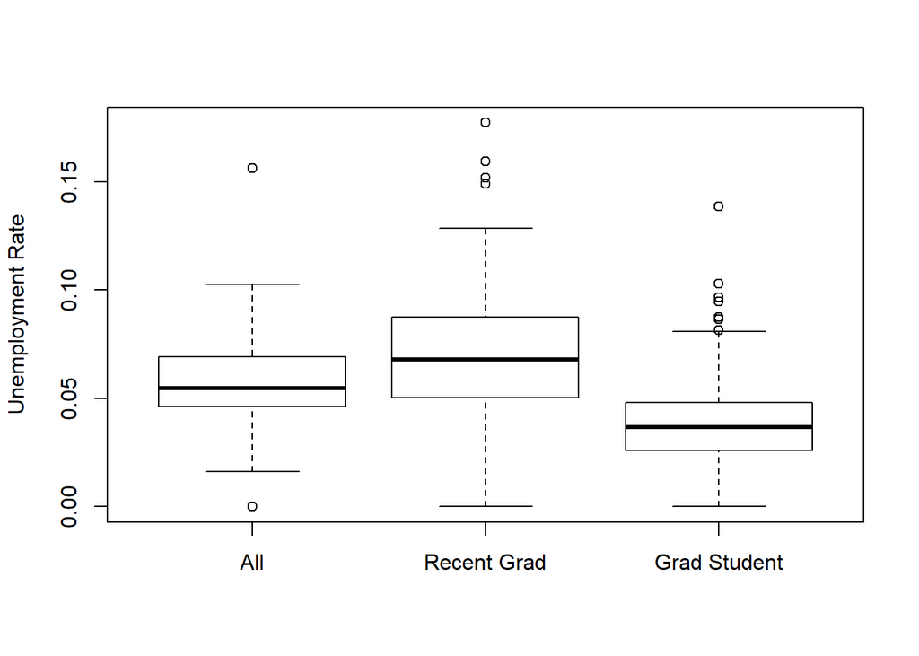

```r
# Box plot
unempl <- cbind(all_ages_df$Unemployment_rate, recent_grad_df$Unemployment_rate, grad_df$Grad_unemployment_rate)
boxplot(unempl,names = c("All", "Recent Grad", "Grad Student"), ylab = "Unemployment Rate")
```

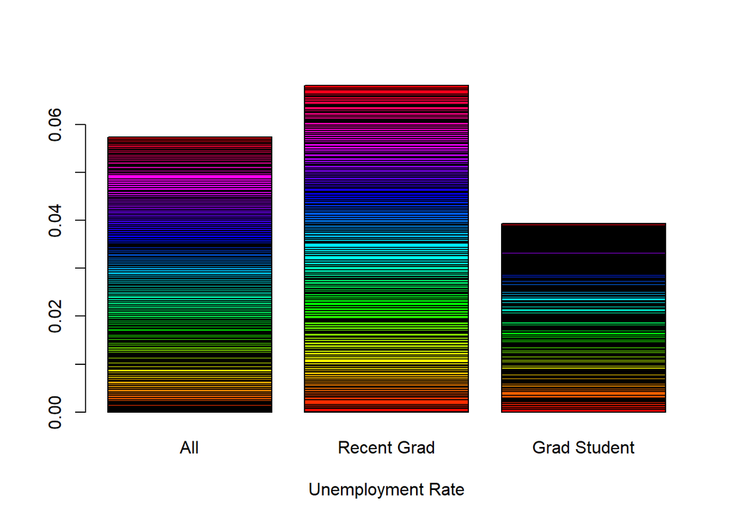

```r
#Bar plot
unempl <- cbind(all_ages_df$Unemployment_rate, recent_grad_df$Unemployment_rate, grad_df$Grad_unemployment_rate)
barplot(unempl/nrow(unempl), names.arg = c("All", "Recent Grad", "Grad Student"), xlab = "Unemployment Rate", col = rainbow(nrow(unempl)))
```

> *It appears that people holding only a Bachelor’s degree have nearly twice as high median unemployment as those with higher degrees. This suggests that having a graduate degree improves a person’s chance at finding a job*.

### Now we will also look at median income(salary) for the three categories.

```r
summary(all_ages_df$Median)
```

```
##    Min. 1st Qu.  Median    Mean 3rd Qu.    Max.
##   35000   46000   53000   56816   65000  125000
```

```r
summary(grad_df$Grad_median)
```

```
##    Min. 1st Qu.  Median    Mean 3rd Qu.    Max.
##   47000   65000   75000   76756   90000  135000
```

```r
summary(recent_grad_df$Median)
```

```
##    Min. 1st Qu.  Median    Mean 3rd Qu.    Max.
##   22000   33000   36000   40151   45000  110000
```

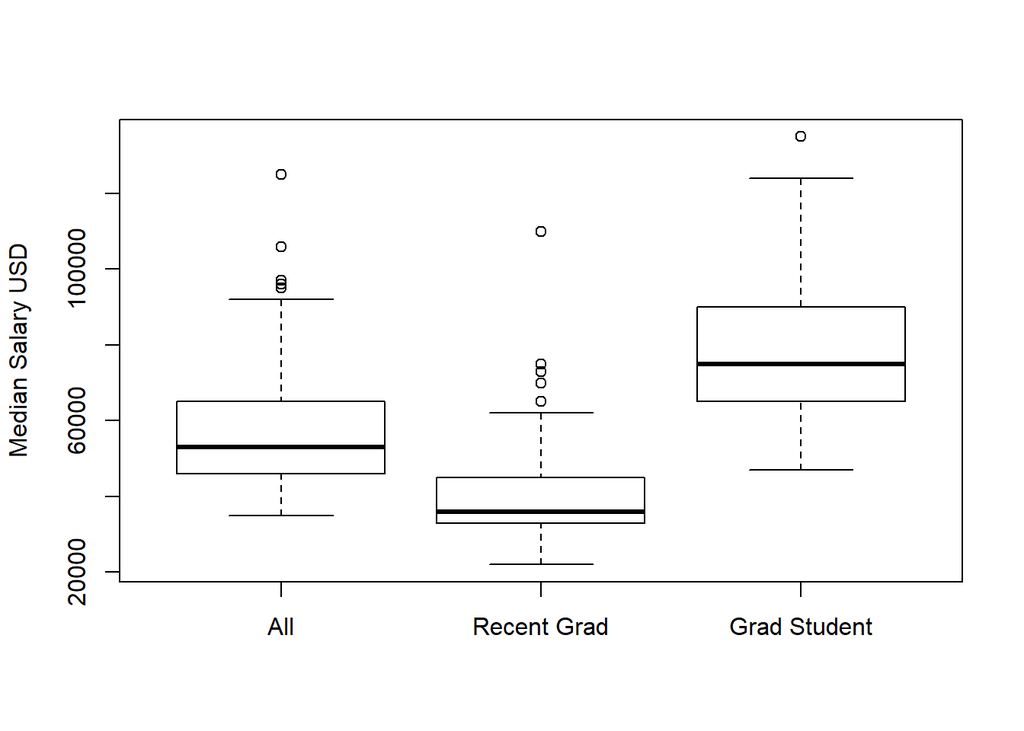

```r
# Box plot
medsal <- cbind(all_ages_df$Median, recent_grad_df$Median, grad_df$Grad_median)
boxplot(medsal, names = c("All", "Recent Grad", "Grad Student"), ylab = "Median Salary USD")
```

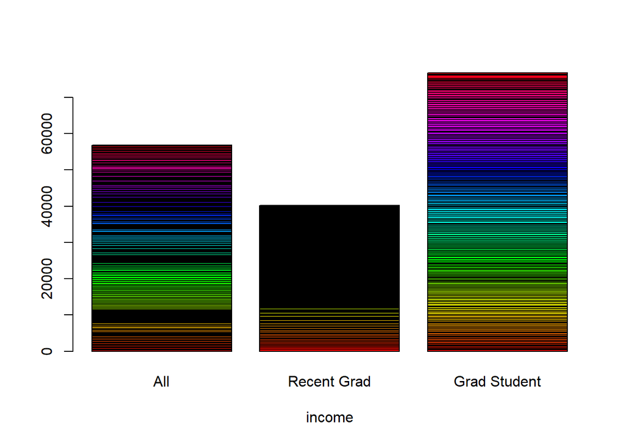

```r
#Barplot
income <- cbind(all_ages_df$Median, recent_grad_df$Median, grad_df$Grad_median)
barplot(income/nrow(income), names.arg = c("All", "Recent Grad", "Grad Student"), xlab = "income", col = rainbow(nrow(income)))
```

> *We see from these graphs that the median salary of the graduate students is considered a high outlier for the recent graduate set, and the medial salary for the recent graduate data set is a low outlier for the graduate student set. This suggests that getting a graduate degree greatly improves earning potential*.

### **Part 4 - Inference**

- **Check conditions**
- **Theoretical inference (if possible) - hypothesis test and confidence interval**
- **Simulation based inference - hypothesis test and confidence interval**
- **Brief description of methodology that reflects your conceptual understanding**

### **Statistical test (Chi-square test (χ<sup>2</sup>))**

#### It is not enough to simply look at graphs and draw conclusions as to whether our hypothesis is correct. Further statistical tests need to be preformed to test if what the graphs tell us is actually significant. To that end, we perform χ2 tests for independence, as this test is used to check for significance of a categorical variable like employed vs. unemployed6. Our null hypothesis is that major choice is independent of employment status. The alternative hypothesis is that employment status depends on major choice.

```r
# For user-freindliness we'll pull major, number employed, number unemployed.
# for all ages
all_age_contin <- all_ages_df %>% dplyr::select(Major, Employed, Unemployed)
head(all_age_contin)
```

```
##                                   Major Employed Unemployed
## 1                   GENERAL AGRICULTURE    90245       2423
## 2 AGRICULTURE PRODUCTION AND MANAGEMENT    76865       2266
## 3                AGRICULTURAL ECONOMICS    26321        821
## 4                       ANIMAL SCIENCES    81177       3619
## 5                          FOOD SCIENCE    17281        894
## 6            PLANT SCIENCE AND AGRONOMY    63043       2070
```

```r
chisq.test(all_age_contin[,-1])
```

```
##
##  Pearson's Chi-squared test
##
## data:  all_age_contin[, -1]
## X-squared = 96644, df = 172, p-value < 2.2e-16
```

```r
# for all grad
grd_st_contin <- grad_df %>% dplyr::select(Major, Grad_employed, Grad_unemployed)
head(grd_st_contin)
```

```
##                                    Major Grad_employed Grad_unemployed
## 1                  CONSTRUCTION SERVICES          7098             681
## 2      COMMERCIAL ART AND GRAPHIC DESIGN         40492            2482
## 3                 HOSPITALITY MANAGEMENT         18368            1465
## 4 COSMETOLOGY SERVICES AND CULINARY ARTS          3590             316
## 5             COMMUNICATION TECHNOLOGIES          7512             466
## 6                        COURT REPORTING          1008               0
```

```r
chisq.test(grd_st_contin[,-1])
```

```
##
##  Pearson's Chi-squared test
##
## data:  grd_st_contin[, -1]
## X-squared = 62013, df = 172, p-value < 2.2e-16
```

```r
#for all recent grad
rct_gr_contin <- recent_grad_df %>% dplyr::select(Major,Employed,Unemployed) %>% filter(Major != "MILITARY TECHNOLOGIES" )
head(rct_gr_contin)
```

```
##                                       Major Employed Unemployed
## 1                     PETROLEUM ENGINEERING     1976         37
## 2            MINING AND MINERAL ENGINEERING      640         85
## 3                 METALLURGICAL ENGINEERING      648         16
## 4 NAVAL ARCHITECTURE AND MARINE ENGINEERING      758         40
## 5                      CHEMICAL ENGINEERING    25694       1672
## 6                       NUCLEAR ENGINEERING     1857        400
```

```r
chisq.test(rct_gr_contin[,-1])
```

```
##
##  Pearson's Chi-squared test
##
## data:  rct_gr_contin[, -1]
## X-squared = 29941, df = 171, p-value < 2.2e-16
```

> *As with the other two cases,we reject the null and accept the alternative that choice of major affects unemployment rate. Thus, regardless of degree level your choice of major will affect your unemployment rate. Generally speaking you’ll have better chances of finding a job in certain majors as compared to other majors*.

### **Linear Regression - unemployment rate and median salary**

#### Job market pressure can have an impact on both median salary and unemployment rate. If a field has low demand but high supply this can depress the salary and increase the unemployment rate. Conversely, a high demand/low supply field will see increased salaries and decreased unemployment rates. Another effect to consider is that people in over-subscribed field may spend a greater time looking for a job, which would also decrease median salary as they may be unemployed or underemployed during the job hunt. This effect could show in the data as a correlation between unemployment rate and salary.

#### To test if there is a connection between unemployment rate and median salary, we will take the “all_ages” data set and create linear regression models. If the residuals of the model do not show the necessary behavior of Normal Distribution and Constant Variance, we will perform a **Box-Cox transformation** on the data to get an exponential factor to improve the model.

```r
# model 1
model1 <- lm(all_ages_df$Median ~ all_ages_df$Unemployment_rate)
summary(model1)
```

```
##
## Call:
## lm(formula = all_ages_df$Median ~ all_ages_df$Unemployment_rate)
##
## Residuals:
##    Min     1Q Median     3Q    Max
## -23370  -8995  -3272   8079  64676
##
## Coefficients:
##                               Estimate Std. Error t value Pr(>|t|)
## (Intercept)                      70097       3380  20.738  < 2e-16 ***
## all_ages_df$Unemployment_rate  -231551      55906  -4.142 5.41e-05 ***
## ---
## Signif. codes:  0 '***' 0.001 '**' 0.01 '*' 0.05 '.' 0.1 ' ' 1
##
## Residual standard error: 14060 on 171 degrees of freedom
## Multiple R-squared:  0.09117,    Adjusted R-squared:  0.08586
## F-statistic: 17.15 on 1 and 171 DF,  p-value: 5.406e-05
```

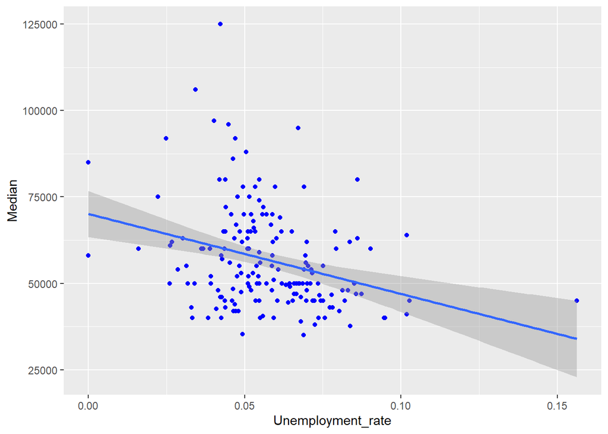

```r
# Plot
ggplot(all_ages_df, aes(x = Unemployment_rate, y = Median)) +geom_point(color = 'blue')+geom_smooth(method = "lm", formula = y~x)
```

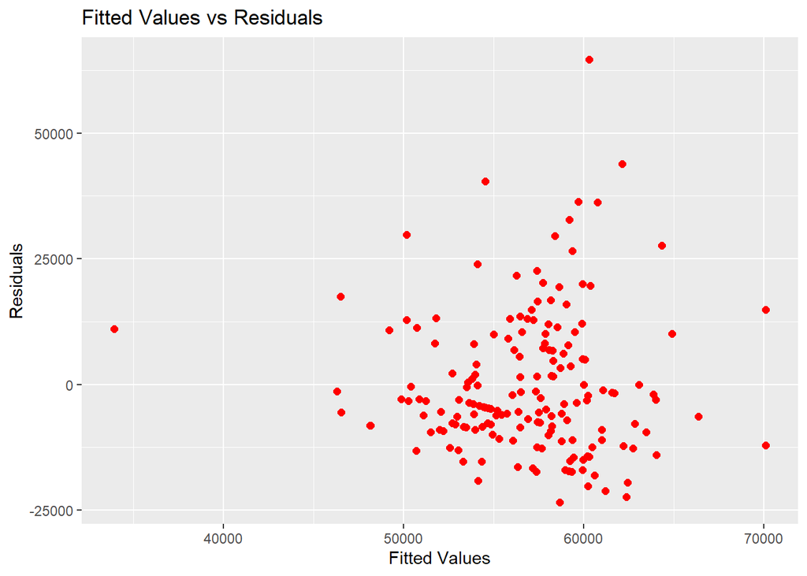

```r
# Residual plot
ggplot(model1, aes(.fitted, .resid)) + geom_point(color = "red", size=2) +labs(title = "Fitted Values vs Residuals") +labs(x = "Fitted Values") +labs(y = "Residuals")
```

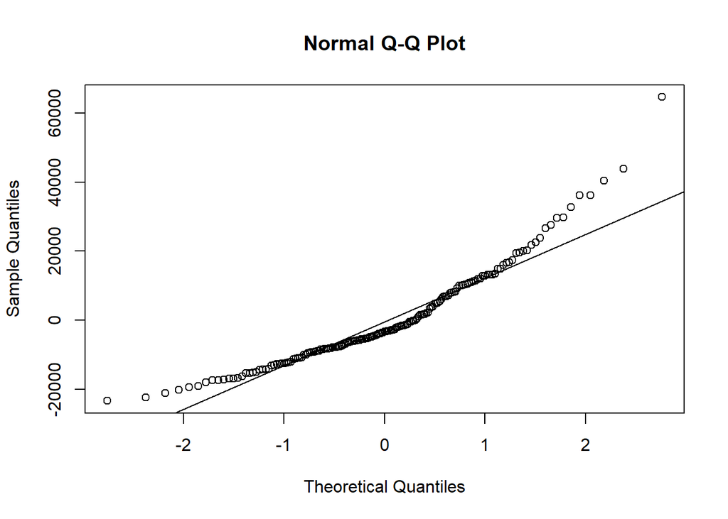

```r
# Normal plot
qqnorm(resid(model1))
qqline(resid(model1))
```

```r
# An outlier is effecting our linear regression. Box Cox will be used to correct.
m1 <- boxcox(model1)
```

[figure not shown]

```r
m1_df <- as.data.frame(m1)
(optimal_lambda <- m1_df[which.max(m1$y),1])
```

```
## [1] -1.070707
```

```r
#model 2
model2 <- lm(all_ages_df$Median^optimal_lambda ~ all_ages_df$Unemployment_rate)
summary(model2)
```

```
##
## Call:
## lm(formula = all_ages_df$Median^optimal_lambda ~ all_ages_df$Unemployment_rate)
##
## Residuals:
##        Min         1Q     Median         3Q        Max
## -4.646e-06 -1.475e-06  2.614e-07  1.295e-06  5.141e-06
##
## Coefficients:
##                                Estimate Std. Error t value Pr(>|t|)
## (Intercept)                   6.755e-06  4.666e-07  14.476  < 2e-16 ***
## all_ages_df$Unemployment_rate 3.272e-05  7.718e-06   4.239 3.66e-05 ***
## ---
## Signif. codes:  0 '***' 0.001 '**' 0.01 '*' 0.05 '.' 0.1 ' ' 1
##
## Residual standard error: 1.941e-06 on 171 degrees of freedom
## Multiple R-squared:  0.09509,    Adjusted R-squared:  0.0898
## F-statistic: 17.97 on 1 and 171 DF,  p-value: 3.664e-05
```

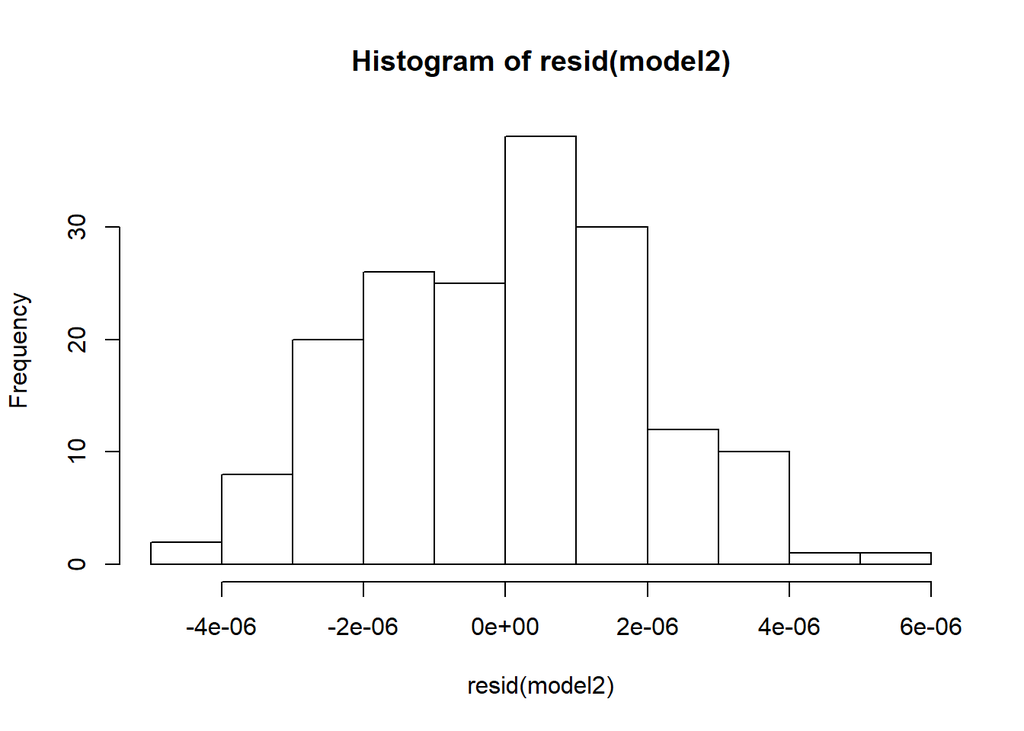

```r
#plot
hist(resid(model2))
```

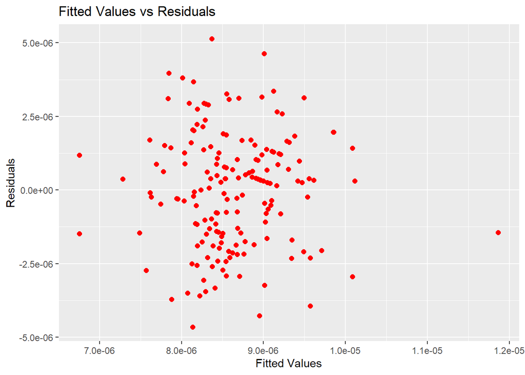

```r
# Residual plot
ggplot(model2, aes(.fitted, .resid)) + geom_point(color = "red", size=2) +labs(title = "Fitted Values vs Residuals") +labs(x = "Fitted Values") +labs(y = "Residuals")
```

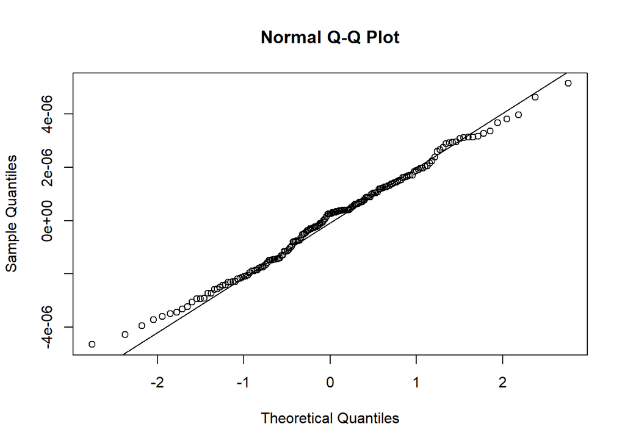

```r
# Normal plot
qqnorm(resid(model2))
qqline(resid(model2))
```

```r
# An outlier is effecting our linear regression. Box Cox will be used to correct.
m2 <- boxcox(model2)
```

[figure not shown]

### **Part 5 - Conclusion**

### **Write a brief summary of your findings without repeating your statements from earlier. Also include a discussion of what you have learned about your research question and the data you collected. You may also want to include ideas for possible future research.**

### *We find that choice in college major has a significant effect on median salary and unemployment rate.This effect is seen at all age levels. Higher salaries and lower unemployment tend to favor some college majors. There is a statistically, but not necessarily practically, significance between unemployment rate and median pay.*

### **Future Work**

> *These data are only represent a single point in time. Measuring trends is important for perspective college student, as they need to be able to predict what the job market is going to look like when they graduate. These trends may also influence choices in graduate study. Therefore it is necessary to repeat these surveys at regular intervals, and add time series analysis to the above analysis*.

> *In the graduate student data, no differentiation is made between masters, doctorates or professional degrees. Adding a column to future surveys will be useful as more detailed analysis can be made in terms of how level of attainment will affect earnings an unemployment rates*.